# p8105_hw1_hh3043

Haitian Huang

2023-09-22

# Problem 1

There are 15 variables:origin,year,month,day,hour, temperature,dewpoint in F,humid,wind direction,wind speed, gust speed,precipitation,pressure,visibility and data and hour of recording as POSIXct date.

There are 358 rows and 15 columns.

The mean of temperatures is 39.5821229.

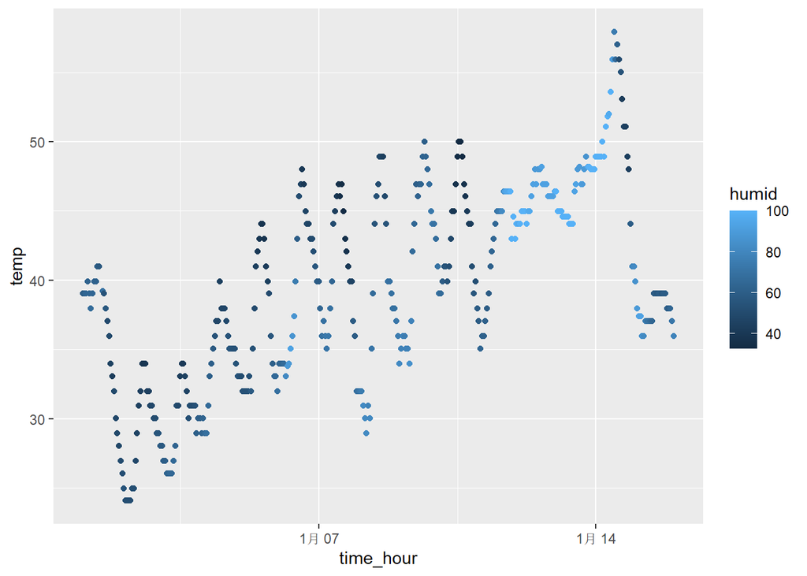

# problem 2

```r
library(tidyverse)
df =
  tibble(
  vec_num = rnorm(10),
  vec_log = vec_num>0,
  vec_character = sample(c('w','e'),size=10,replace = TRUE),
  vec_factor = factor(c(sample(c('dog','cat','mouse'),size=10,replace = TRUE)))
)
```

```r
mean(pull(df,vec_num))
mean(pull(df,vec_log))
mean(pull(df,vec_character))
mean(pull(df,vec_factor))
```

[output not shown]

The mean() method works for random sample and logic vector,but NA is returned for vector of character and vector of factor.The mean of random sample is 0.2693434,and the mean of logic vector is 0.4.

```r
as.numeric(pull(df,vec_num))
as.numeric(pull(df,vec_log))
as.numeric(pull(df,vec_character))
as.numeric(pull(df,vec_factor))
```

[output not shown]

The as.numeric method works for random sample,logic vector and vector of factor,returning NA for vector of character.Of course it works for random sample,because random sample is already in numeric form.

As for vector of factor,there is no clear statistical significance of mean,since numbers are transferred according to the order of levels.It might be the reason why mean() does not work on it.